# Project: Investigate Dataset of No-Show for Medical appoinments in brazil.

- Introduction
- Data Wrangling
- Exploratory Data Analysis
- Limitations
- Conclusions

## Introduction

This is a data analysis of 100K medical appoinments in brazil in the period between April to June of 2016. This dataset is oriented about whether the patient showed up for the appoinment or not. It contains data about (PatientId, AppointmentID, Gender, ScheduledDay, AppointmentDay, Age, Neighbourhood, scholarship i.e insurance, if the patient has any of Hypertension, Diabetes, Alcoholism, Handicapped, if they recived SMS, and lastely and most importantly the No-show data (kindly notice here: yes or 1 here means that they didn't show up!).

[Visit this dataset in kaggle.com](https://www.kaggle.com/joniarroba/noshowappointments) or download it directly!

Research Questions:  
1- What is the rate of show vs no-show?  
2- What is the gender percentage?  
3- How did medical diseases affected the rate of show vs no-show?  
4- How did Age affected the rate of show vs no-show?  
5- How did receving a SMS message affected the rate of show vs no-show?  
6- How did having a scholarship(i.e. insurance) affected the rate of show vs no-show?  
7- How did Neighbourhood affected the rate of show vs no-show?  
8- How did receving SMS affect the ratio of no-show between males and females?  
9- How did Hypertension affected the ratio of not showing up males and females?  
10- How did Alcoholism affected the ratio of not showing up males and females?  
11- How did Diabetes affected the ratio of not showing up males and females?

```python
# Use this cell to set up import statements for all of the packages that you
#   plan to use.
import numpy as np
import pandas as pd
import matplotlib.pyplot as plt
import seaborn as sns
%matplotlib inline
```

## Data Wrangling

### General Properties

```python
# Load your data and print out a few lines. Perform operations to inspect data
#   types and look for instances of missing or possibly errant data.
df = pd.read_csv('noshow.csv')
df
```

|  | PatientId | AppointmentID | Gender | ScheduledDay | AppointmentDay | Age | Neighbourhood | Scholarship | Hypertension | Diabetes | Alcoholism | Handcap | SMS_received | No-show |
| --- | --- | --- | --- | --- | --- | --- | --- | --- | --- | --- | --- | --- | --- | --- |
| 0 | 2.987250e+13 | 5642903 | F | 2016-04-29T18:38:08Z | 2016-04-29T00:00:00Z | 62 | JARDIM DA PENHA | 0 | 1 | 0 | 0 | 0 | 0 | No |
| 1 | 5.589980e+14 | 5642503 | M | 2016-04-29T16:08:27Z | 2016-04-29T00:00:00Z | 56 | JARDIM DA PENHA | 0 | 0 | 0 | 0 | 0 | 0 | No |
| 2 | 4.262960e+12 | 5642549 | F | 2016-04-29T16:19:04Z | 2016-04-29T00:00:00Z | 62 | MATA DA PRAIA | 0 | 0 | 0 | 0 | 0 | 0 | No |
| 3 | 8.679510e+11 | 5642828 | F | 2016-04-29T17:29:31Z | 2016-04-29T00:00:00Z | 8 | PONTAL DE CAMBURI | 0 | 0 | 0 | 0 | 0 | 0 | No |
| 4 | 8.841190e+12 | 5642494 | F | 2016-04-29T16:07:23Z | 2016-04-29T00:00:00Z | 56 | JARDIM DA PENHA | 0 | 1 | 1 | 0 | 0 | 0 | No |
| ... | ... | ... | ... | ... | ... | ... | ... | ... | ... | ... | ... | ... | ... | ... |
| 110522 | 2.572130e+12 | 5651768 | F | 2016-05-03T09:15:35Z | 2016-06-07T00:00:00Z | 56 | MARIA ORTIZ | 0 | 0 | 0 | 0 | 0 | 1 | No |
| 110523 | 3.596270e+12 | 5650093 | F | 2016-05-03T07:27:33Z | 2016-06-07T00:00:00Z | 51 | MARIA ORTIZ | 0 | 0 | 0 | 0 | 0 | 1 | No |
| 110524 | 1.557660e+13 | 5630692 | F | 2016-04-27T16:03:52Z | 2016-06-07T00:00:00Z | 21 | MARIA ORTIZ | 0 | 0 | 0 | 0 | 0 | 1 | No |
| 110525 | 9.213490e+13 | 5630323 | F | 2016-04-27T15:09:23Z | 2016-06-07T00:00:00Z | 38 | MARIA ORTIZ | 0 | 0 | 0 | 0 | 0 | 1 | No |
| 110526 | 3.775120e+14 | 5629448 | F | 2016-04-27T13:30:56Z | 2016-06-07T00:00:00Z | 54 | MARIA ORTIZ | 0 | 0 | 0 | 0 | 0 | 1 | No |

110527 rows × 14 columns

```python
df.shape
```

```
(110527, 14)
```

```python
df.describe()
```

|  | PatientId | AppointmentID | Age | Scholarship | Hypertension | Diabetes | Alcoholism | Handcap | SMS_received |
| --- | --- | --- | --- | --- | --- | --- | --- | --- | --- |
| count | 1.105270e+05 | 1.105270e+05 | 110527.000000 | 110527.000000 | 110527.000000 | 110527.000000 | 110527.000000 | 110527.000000 | 110527.000000 |
| mean | 1.474963e+14 | 5.675305e+06 | 37.088874 | 0.098266 | 0.197246 | 0.071865 | 0.030400 | 0.022248 | 0.321026 |
| std | 2.560949e+14 | 7.129575e+04 | 23.110205 | 0.297675 | 0.397921 | 0.258265 | 0.171686 | 0.161543 | 0.466873 |
| min | 3.920000e+04 | 5.030230e+06 | -1.000000 | 0.000000 | 0.000000 | 0.000000 | 0.000000 | 0.000000 | 0.000000 |
| 25% | 4.172615e+12 | 5.640286e+06 | 18.000000 | 0.000000 | 0.000000 | 0.000000 | 0.000000 | 0.000000 | 0.000000 |
| 50% | 3.173180e+13 | 5.680573e+06 | 37.000000 | 0.000000 | 0.000000 | 0.000000 | 0.000000 | 0.000000 | 0.000000 |
| 75% | 9.439170e+13 | 5.725524e+06 | 55.000000 | 0.000000 | 0.000000 | 0.000000 | 0.000000 | 0.000000 | 1.000000 |
| max | 9.999820e+14 | 5.790484e+06 | 115.000000 | 1.000000 | 1.000000 | 1.000000 | 1.000000 | 4.000000 | 1.000000 |

There's some age values with mins which is invalid!

```python
df.info()
```

```
<class 'pandas.core.frame.DataFrame'>
RangeIndex: 110527 entries, 0 to 110526
Data columns (total 14 columns):
 #   Column          Non-Null Count   Dtype
---  ------          --------------   -----
 0   PatientId       110527 non-null  float64
 1   AppointmentID   110527 non-null  int64
 2   Gender          110527 non-null  object
 3   ScheduledDay    110527 non-null  object
 4   AppointmentDay  110527 non-null  object
 5   Age             110527 non-null  int64
 6   Neighbourhood   110527 non-null  object
 7   Scholarship     110527 non-null  int64
 8   Hypertension    110527 non-null  int64
 9   Diabetes        110527 non-null  int64
 10  Alcoholism      110527 non-null  int64
 11  Handcap         110527 non-null  int64
 12  SMS_received    110527 non-null  int64
 13  No-show         110527 non-null  object
dtypes: float64(1), int64(8), object(5)
memory usage: 11.8+ MB
```

Data containes 110527 entries with 14 columns!

```python
df.isnull().sum()
```

```
PatientId         0
AppointmentID     0
Gender            0
ScheduledDay      0
AppointmentDay    0
Age               0
Neighbourhood     0
Scholarship       0
Hypertension      0
Diabetes          0
Alcoholism        0
Handcap           0
SMS_received      0
No-show           0
dtype: int64
```

No empty cells found!

```python
df.duplicated().sum()
```

```
0
```

No duplicated cells found!

```python
df['Age'].unique()
```

```
array([ 62,  56,   8,  76,  23,  39,  21,  19,  30,  29,  22,  28,  54,
        15,  50,  40,  46,   4,  13,  65,  45,  51,  32,  12,  61,  38,
        79,  18,  63,  64,  85,  59,  55,  71,  49,  78,  31,  58,  27,
         6,   2,  11,   7,   0,   3,   1,  69,  68,  60,  67,  36,  10,
        35,  20,  26,  34,  33,  16,  42,   5,  47,  17,  41,  44,  37,
        24,  66,  77,  81,  70,  53,  75,  73,  52,  74,  43,  89,  57,
        14,   9,  48,  83,  72,  25,  80,  87,  88,  84,  82,  90,  94,
        86,  91,  98,  92,  96,  93,  95,  97, 102, 115, 100,  99,  -1],
      dtype=int64)
```

An age value with -1 is found, to be corrected in the cleaning section below!

```python
df[df.Age < 0]['Age']
```

```
99832   -1
Name: Age, dtype: int64
```

```python
df['Gender'].unique()
```

```
array(['F', 'M'], dtype=object)
```

```python
df['Scholarship'].unique()
```

```
array([0, 1], dtype=int64)
```

```python
df['Hypertension'].unique()
```

```
array([1, 0], dtype=int64)
```

```python
df['Diabetes'].unique()
```

```
array([0, 1], dtype=int64)
```

```python
df['Alcoholism'].unique()
```

```
array([0, 1], dtype=int64)
```

```python
df['Handcap'].unique()
```

```
array([0, 1, 2, 3, 4], dtype=int64)
```

All columns of diseases above is good except for handicappnes, which seems to be of different grades.

```python
df['SMS_received'].unique()
```

```
array([0, 1], dtype=int64)
```

```python
df['No-show'].unique()
```

```
array(['No', 'Yes'], dtype=object)
```

The no-show data here is assinged by yes or no values, will be converted to zeros and ones to be easily plotted.

### Data Cleaning

```python
# Rename Columns
df.rename(columns = {'Hipertension': 'Hypertension', 'Handcap': 'Handicap','No-show':'No_show'}, inplace = True)
```

Inappropiate column names is corrected!

```python
# Convert AppointmentDay and ScheduledDay from String to DateTime format
df['ScheduledDay'] = pd.to_datetime(df['ScheduledDay'])
df['AppointmentDay'] = pd.to_datetime(df['AppointmentDay'])
```

Dates in scheduling day and appoinment day are converted to be read as date not just numbers!

```python
# Remove below zero age
df = df[df.Age != -1]
```

Below zero age is removed!

```python
# Replace the no show column from 'no and yes' to 'zeros and ones' also converting it to an intger data type
df.No_show.replace(['No', 'Yes'], [0,1], inplace = True)
df['No_show'] = df['No_show'].astype('int64')
```

```python
#Rechecking no-show column
df['No_show'].unique()
```

```
array([0, 1], dtype=int64)
```

```python
df['No_show']
```

```
0         0
1         0
2         0
3         0
4         0
         ..
110522    0
110523    0
110524    0
110525    0
110526    0
Name: No_show, Length: 110526, dtype: int64
```

```python
#changing all numeric coulmns to integrs
df['Age'] = df['Age'].astype('int64')
df['Scholarship'] = df['Scholarship'].astype('int64')
df['Hypertension'] = df['Hypertension'].astype('int64')
df['Diabetes'] = df['Diabetes'].astype('int64')
df['Alcoholism'] = df['Alcoholism'].astype('int64')
df['Handicap'] = df['Handicap'].astype('int64')
df['SMS_received'] = df['SMS_received'].astype('int64')
```

[output not shown]

Now we confirmed that all data is clean with no null or duplicate data and we found out the -1 and removed it to not affect the age data in an inappropiate way, replaced No show cloumn into zeros and ones, converted all numerical clomns (zero and ones data) into the right data type (integr) to be easily plotted.

```python
df
```

|  | PatientId | AppointmentID | Gender | ScheduledDay | AppointmentDay | Age | Neighbourhood | Scholarship | Hypertension | Diabetes | Alcoholism | Handicap | SMS_received | No_show |
| --- | --- | --- | --- | --- | --- | --- | --- | --- | --- | --- | --- | --- | --- | --- |
| 0 | 2.987250e+13 | 5642903 | F | 2016-04-29 18:38:08+00:00 | 2016-04-29 00:00:00+00:00 | 62 | JARDIM DA PENHA | 0 | 1 | 0 | 0 | 0 | 0 | 0 |
| 1 | 5.589980e+14 | 5642503 | M | 2016-04-29 16:08:27+00:00 | 2016-04-29 00:00:00+00:00 | 56 | JARDIM DA PENHA | 0 | 0 | 0 | 0 | 0 | 0 | 0 |
| 2 | 4.262960e+12 | 5642549 | F | 2016-04-29 16:19:04+00:00 | 2016-04-29 00:00:00+00:00 | 62 | MATA DA PRAIA | 0 | 0 | 0 | 0 | 0 | 0 | 0 |
| 3 | 8.679510e+11 | 5642828 | F | 2016-04-29 17:29:31+00:00 | 2016-04-29 00:00:00+00:00 | 8 | PONTAL DE CAMBURI | 0 | 0 | 0 | 0 | 0 | 0 | 0 |
| 4 | 8.841190e+12 | 5642494 | F | 2016-04-29 16:07:23+00:00 | 2016-04-29 00:00:00+00:00 | 56 | JARDIM DA PENHA | 0 | 1 | 1 | 0 | 0 | 0 | 0 |
| ... | ... | ... | ... | ... | ... | ... | ... | ... | ... | ... | ... | ... | ... | ... |
| 110522 | 2.572130e+12 | 5651768 | F | 2016-05-03 09:15:35+00:00 | 2016-06-07 00:00:00+00:00 | 56 | MARIA ORTIZ | 0 | 0 | 0 | 0 | 0 | 1 | 0 |
| 110523 | 3.596270e+12 | 5650093 | F | 2016-05-03 07:27:33+00:00 | 2016-06-07 00:00:00+00:00 | 51 | MARIA ORTIZ | 0 | 0 | 0 | 0 | 0 | 1 | 0 |
| 110524 | 1.557660e+13 | 5630692 | F | 2016-04-27 16:03:52+00:00 | 2016-06-07 00:00:00+00:00 | 21 | MARIA ORTIZ | 0 | 0 | 0 | 0 | 0 | 1 | 0 |
| 110525 | 9.213490e+13 | 5630323 | F | 2016-04-27 15:09:23+00:00 | 2016-06-07 00:00:00+00:00 | 38 | MARIA ORTIZ | 0 | 0 | 0 | 0 | 0 | 1 | 0 |
| 110526 | 3.775120e+14 | 5629448 | F | 2016-04-27 13:30:56+00:00 | 2016-06-07 00:00:00+00:00 | 54 | MARIA ORTIZ | 0 | 0 | 0 | 0 | 0 | 1 | 0 |

110526 rows × 14 columns

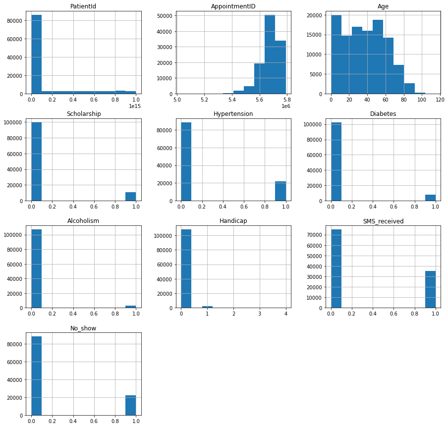

```python
#performing a quick presentation to view the data
df.hist(figsize=[15,15]);
```

## Exploratory Data Analysis

### What is the rate of show vs no-show?

```python
#splitting data frame to show and non-show data frames
No_show = df[df['No_show'] == 1]
show = df[df['No_show'] == 0]
```

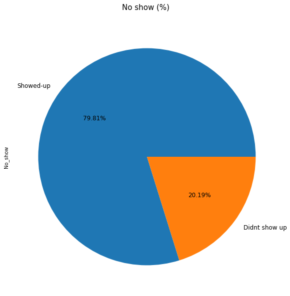

```python
#pie charting the precentage of show vs non_show data
df_pie = df['No_show'].value_counts()
mylabels = ["Showed-up", "Didnt show up"]
noshow = df_pie.plot.pie(labels = mylabels, figsize=(10,10), autopct='%1.2f%%', fontsize = 12)
noshow.set_title('No show (%) \n', fontsize = 15);
```

### What is the gender percentage?

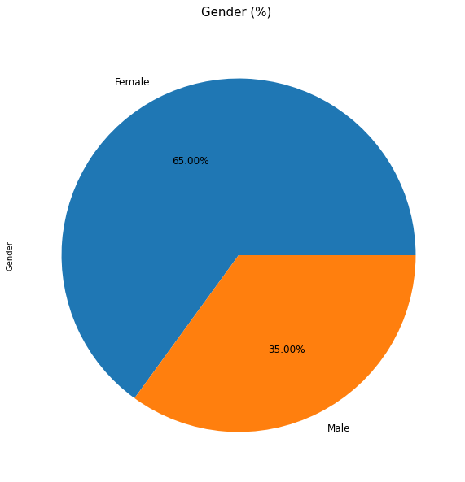

```python
#pie charting the precentage of Genders in the data

df_pie1 = df['Gender'].value_counts()
mylabels1 = ["Female","Male"]
percentage = df_pie1.plot.pie(labels = mylabels1,figsize=(10,10), autopct='%1.2f%%', fontsize = 12)
percentage.set_title('Gender (%) \n', fontsize = 15);
#df.No_show.replace(['No', 'Yes'], [0,1], inplace = True)
```

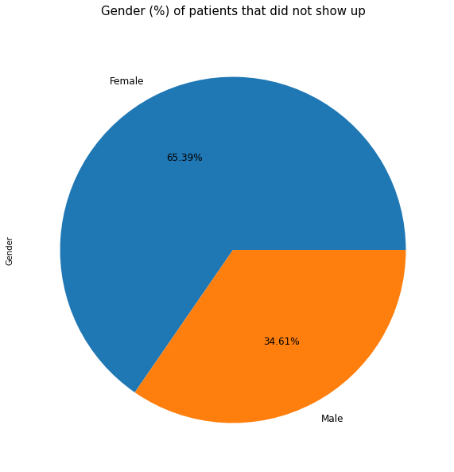

```python
#% of gender that didn't show up
df_pie_gender_no_show = No_show['Gender'].value_counts()
mylabels1 = ["Female","Male"]
gender_no_show = df_pie_gender_no_show.plot.pie(labels = mylabels1,figsize=(10,10), autopct='%1.2f%%', fontsize = 12)
gender_no_show.set_title('Gender (%) of patients that did not show up\n', fontsize = 15);
```

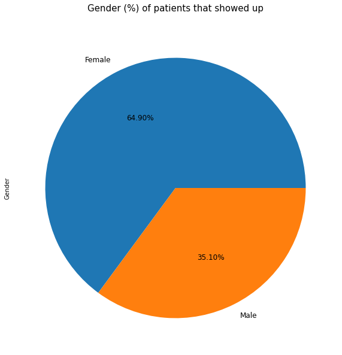

```python
#% of gender that showed up
df_pie_gender_show = show['Gender'].value_counts()
mylabels1 = ["Female","Male"]
gender_show = df_pie_gender_show.plot.pie(labels = mylabels1,figsize=(10,10), autopct='%1.2f%%', fontsize = 12)
gender_show.set_title('Gender (%) of patients that showed up\n', fontsize = 15);
```

There's no correlation between gender and not showing up for the appointment.

### How did medical diseases affected the rate of show vs no-show?

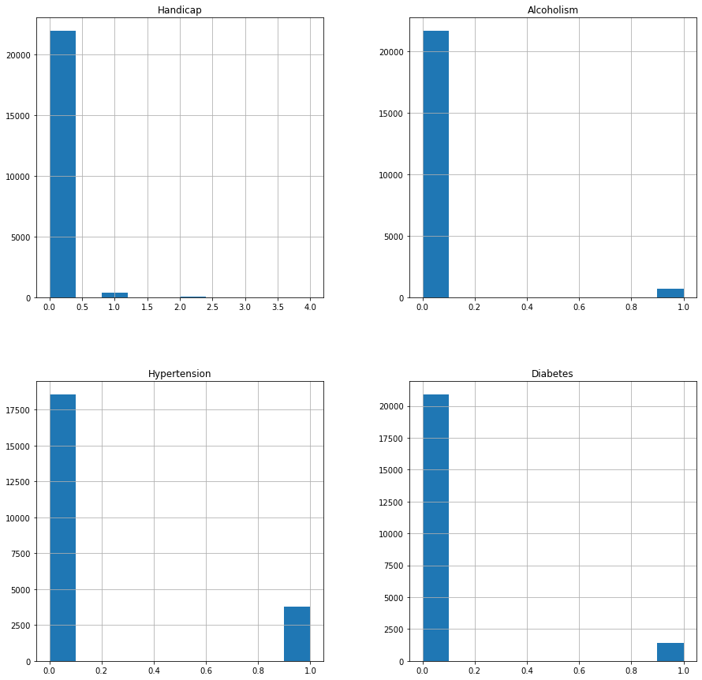

```python
#performing a histograme for medical diseases in non-show appointments
No_show_med=No_show[{'Hypertension','Diabetes', 'Alcoholism', 'Handicap'}]
No_show_med.hist(figsize= (15,15));
```

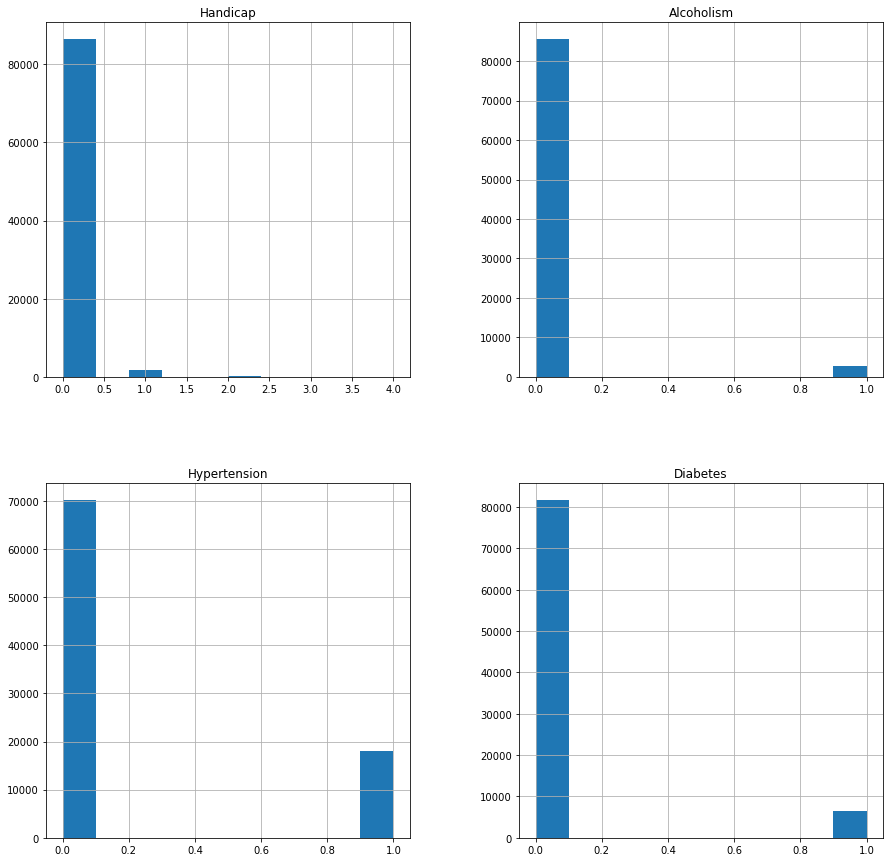

```python
#performing a histogram for medical diseases in show appointments

show_med=show[{'Hypertension','Diabetes', 'Alcoholism', 'Handicap'}]
show_med.hist(figsize= (15,15));
```

Comparing the last two sets of charts: diseases such as Hypertension, Diabetes, Alcoholism and Handicapp didn't affect the show up rates!

### How did Age affected the rate of show vs no-show?

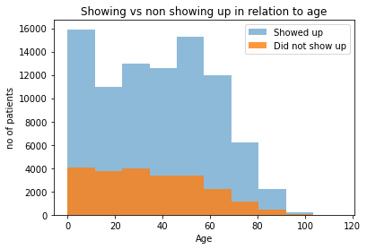

```python
x =No_show['Age']
y =show['Age']

bins = 10

plt.hist(y, bins, alpha=0.5, label='Showed up')
plt.hist(x, bins, alpha=0.8, label='Did not show up')
plt.ylabel('no of patients')
plt.xlabel('Age')
plt.rcParams["figure.figsize"] = (15,15)
plt.title("Showing vs non showing up in relation to age")


plt.legend(loc='upper right');
```

### How did receving SMS affect the ratio of no-show between males and females?

[figure not shown]

```python
#df
#No_show
#show_males = show[show['Gender']=='M']
#show_females = show[show['Gender']=='F']
#No_show_males_sms

No_show_males = No_show[No_show['Gender']=='M']
No_show_females = No_show[No_show['Gender']=='F']

x = No_show_males['SMS_received']
y = No_show_females['SMS_received']

bins = 10
#smslabels = ["Female","Male"]
plt.hist(y, bins, alpha=0.5, label='Females Not Showing')

plt.hist(x, bins, alpha=0.8, label='Males Not Showing')
plt.ylabel('no of patients')
plt.xlabel('didnot or recived sms')
plt.title("Males Showing up vs females Not showing up in relation to receiving a SMS")


plt.legend(loc='upper right');
```

The ratio between (Males not showing up after not receving a SMS reminder) to (Males not showing up after receving a sms) is higher than Females ones!

### How did Alcoholism affect the ratio of no-show between males and females?

[figure not shown]

```python
y = No_show_males['Alcoholism']
x = No_show_females['Alcoholism']

bins = 10
#smslabels = ["Female","Male"]
plt.hist(x, bins, alpha=0.7, label='Females Not Showing')
plt.hist(y, bins, alpha=0.5, label='Males Not Showing')


plt.ylabel('no of patients')
plt.xlabel('Not Alcoholic or Alcoholic')
plt.title("Males Showing up vs females Not showing up in relation to Alcoholism")


plt.legend(loc='upper right');
```

### How did Hypertension affect the ratio of no-show between males and females?

[figure not shown]

```python
y = No_show_males['Hypertension']
x = No_show_females['Hypertension']

bins = 10
#smslabels = ["Female","Male"]
plt.hist(x, bins, alpha=0.7, label='Females Not Showing')
plt.hist(y, bins, alpha=0.5, label='Males Not Showing')


plt.ylabel('no of patients')
plt.xlabel('Not Hypertensive or Hypertensive')
plt.title("Males Showing up vs females Not showing up in relation to Hypertension")


plt.legend(loc='upper right');
#No_show_males_hypertensive = No_show_males[No_show_males['Hypertension']==1]
#No_show_males_hypertensive.count()
#No_show_males_not_hypertensive = No_show_males[No_show_males['Hypertension']==0]
#No_show_males_not_hypertensive.count()


#No_show_females_hypertensive = No_show_females[No_show_females['Hypertension']==1]
#No_show_females_not_hypertensive = No_show_females[No_show_females['Hypertension']==0]


#No_show_females_hypertension_ratio = No_show_females_hypertensive['Hypertension'].count() / No_show_females['Hypertension'].count() * 100
#No_show_females_hypertension_ratio
```

### How did Hypertension affected the ratio of not showing up males and females?

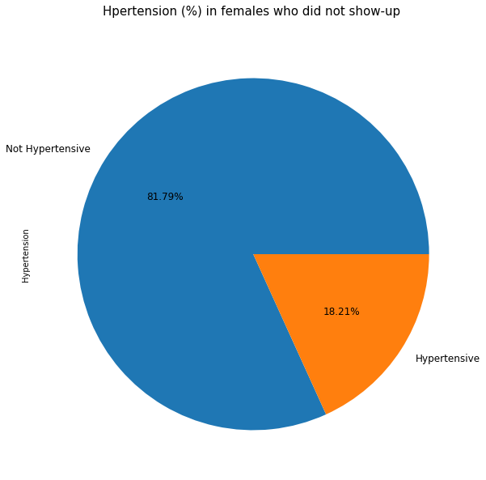

```python
#forming a pie chart to represent effect of Hypertension on not showing up females
df_pie =No_show_females['Hypertension'].value_counts()
mylabels = ["Not Hypertensive", "Hypertensive"]
noshow = df_pie.plot.pie(labels = mylabels, figsize=(10,10), autopct='%1.2f%%', fontsize = 12)
noshow.set_title('Hpertension (%) in females who did not show-up \n', fontsize = 15);
```

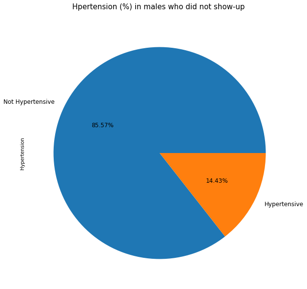

```python
#forming a pie chart to represent effect of Hypertension on not showing up females

df_pie =No_show_males['Hypertension'].value_counts()
mylabels = ["Not Hypertensive", "Hypertensive"]
noshow = df_pie.plot.pie(labels = mylabels, figsize=(10,10), autopct='%1.2f%%', fontsize = 12)
noshow.set_title('Hpertension (%) in males who did not show-up \n', fontsize = 15);
```

In the two last pie charts: Hypertensive females are likely to not show up more than Hypertensive males!

### How did Alcoholism affected the ratio of not showing up males and females?

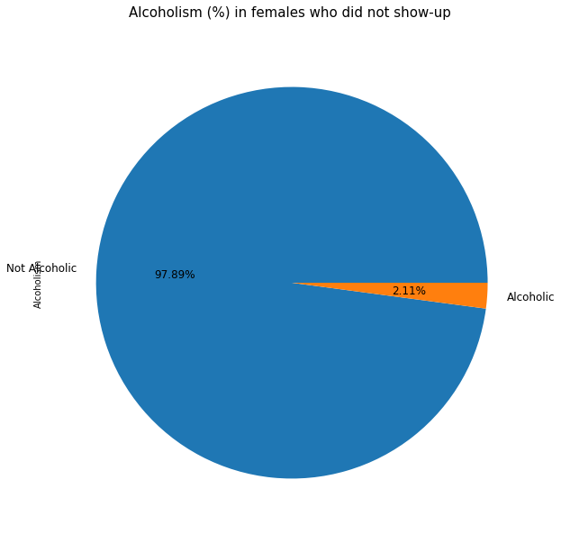

```python
#forming a pie chart to represent effect of Alcholism on not showing up males
df_pie =No_show_females['Alcoholism'].value_counts()
mylabels = ["Not Alcoholic", "Alcoholic"]
noshow = df_pie.plot.pie(labels = mylabels, figsize=(10,10), autopct='%1.2f%%', fontsize = 12)
noshow.set_title('Alcoholism (%) in females who did not show-up \n', fontsize = 15);
```

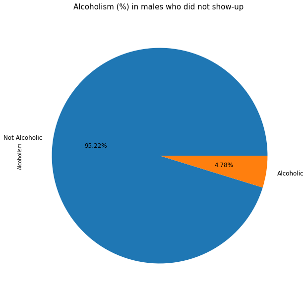

```python
#forming a pie chart to represent effect of Alcholism on not showing up males
df_pie =No_show_males['Alcoholism'].value_counts()
mylabels = ["Not Alcoholic", "Alcoholic"]
noshow = df_pie.plot.pie(labels = mylabels, figsize=(10,10), autopct='%1.2f%%', fontsize = 12)
noshow.set_title('Alcoholism (%) in males who did not show-up \n', fontsize = 15);
```

In the two last pie charts: Alcoholic Males are likely to not show up than Alcoholic females!

### How did Diabetes affected the ratio of not showing up males and females?

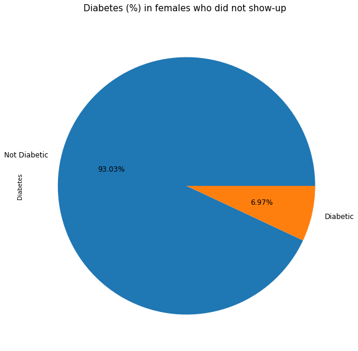

```python
#forming a pie chart to represent effect of diabetes on not showing up females
df_pie =No_show_females['Diabetes'].value_counts()
mylabels = ["Not Diabetic", "Diabetic"]
noshow = df_pie.plot.pie(labels = mylabels, figsize=(10,10), autopct='%1.2f%%', fontsize = 12)
noshow.set_title('Diabetes (%) in females who did not show-up \n', fontsize = 15);
```

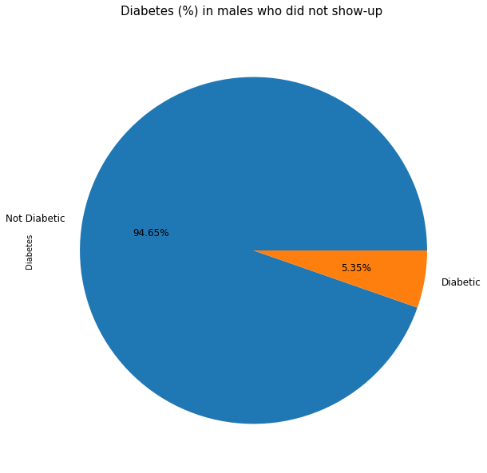

```python
#forming a pie chart to represent effect of diabetes on not showing up males
df_pie =No_show_males['Diabetes'].value_counts()
mylabels = ["Not Diabetic", "Diabetic"]
noshow = df_pie.plot.pie(labels = mylabels, figsize=(10,10), autopct='%1.2f%%', fontsize = 12)
noshow.set_title('Diabetes (%) in males who did not show-up \n', fontsize = 15);
```

In the two last pie charts: Diabetic females are likely to not show up more than Diabetic males!

So in general: females who have medical diseases (except for ALocoholism) didn't show up more than males.

### How did Receving SMS affected the ratio of showing up or not?

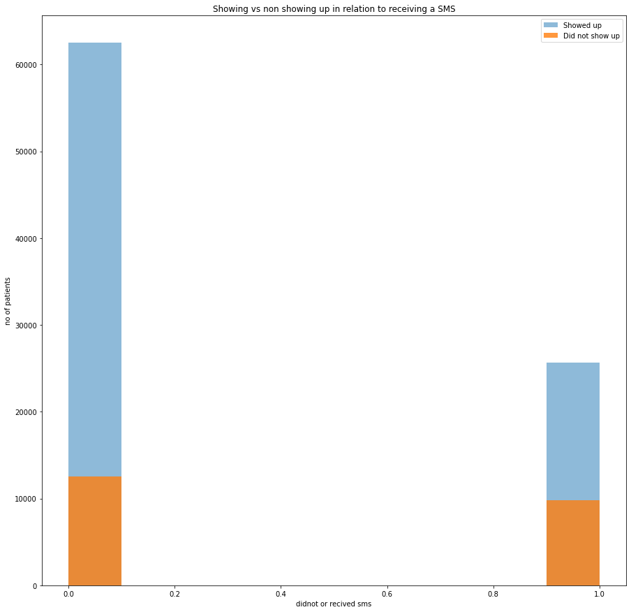

```python
#plotting Receving data frame and its effect of not showing up

x = No_show['SMS_received']
y = show['SMS_received']

bins = 10
plt.hist(y, bins, alpha=0.5, label='Showed up')

plt.hist(x, bins, alpha=0.8, label='Did not show up')
plt.ylabel('no of patients')
plt.xlabel('didnot or recived sms')
plt.title("Showing vs non showing up in relation to receiving a SMS")


plt.legend(loc='upper right');
```

The patients who didn't show up recived sms more than who showed up which is maybe just a coincidence.

### How did Neighbourhood affect the ratio of showing up or not?

```python
#making a new dataframes to include the top ten most neighbourhood in the data
top_ten=list(df['Neighbourhood'].value_counts().nlargest(10).index)

No_show_top_ten = No_show[No_show['Neighbourhood'].isin(top_ten)]
show_top_ten = show[show['Neighbourhood'].isin(top_ten)]
top_ten
```

```
['JARDIM CAMBURI',
 'MARIA ORTIZ',
 'RESISTÊNCIA',
 'JARDIM DA PENHA',
 'ITARARÉ',
 'CENTRO',
 'TABUAZEIRO',
 'SANTA MARTHA',
 'JESUS DE NAZARETH',
 'BONFIM']
```

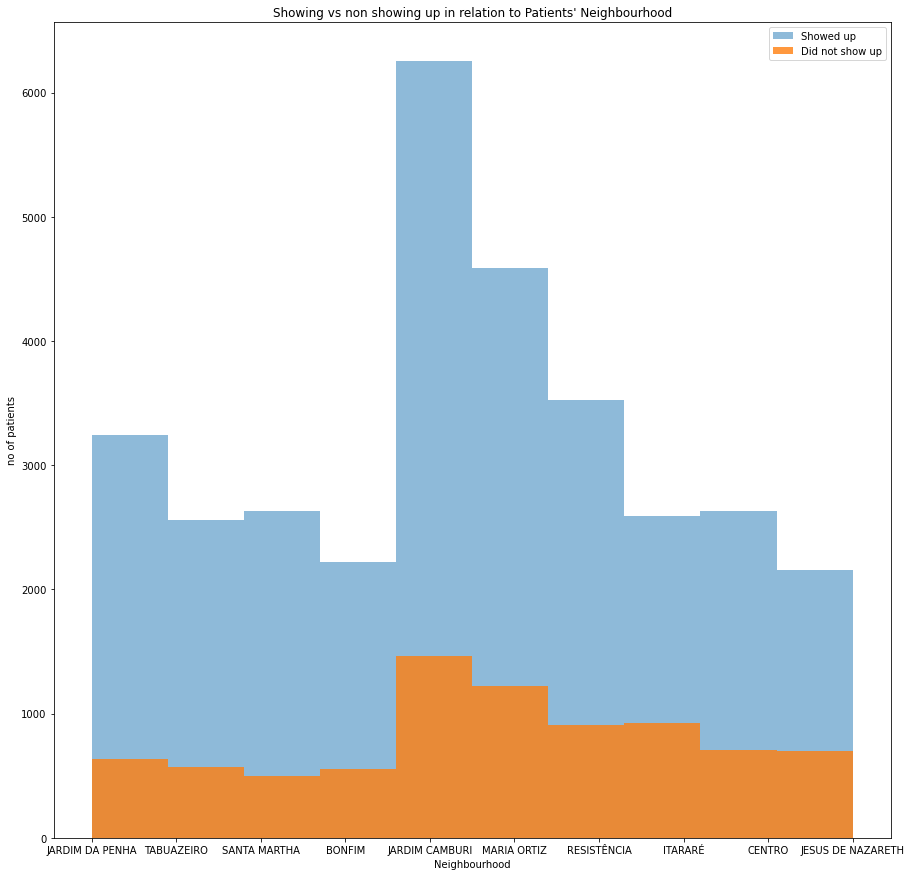

```python
#plotting top ten neighborhood data frame and its effect of not showing up
x = No_show_top_ten['Neighbourhood']
y = show_top_ten['Neighbourhood']

bins = 10

plt.hist(y, bins, alpha=0.5, label='Showed up')
plt.hist(x, bins, alpha=0.8, label='Did not show up')
plt.ylabel('no of patients')
plt.xlabel('Neighbourhood')
plt.rcParams["figure.figsize"] = (15,15)
plt.legend(loc='upper right');
plt.title("Showing vs non showing up in relation to Patients' Neighbourhood");
```

### How did Scholarship affect the ratio of showing up or not?

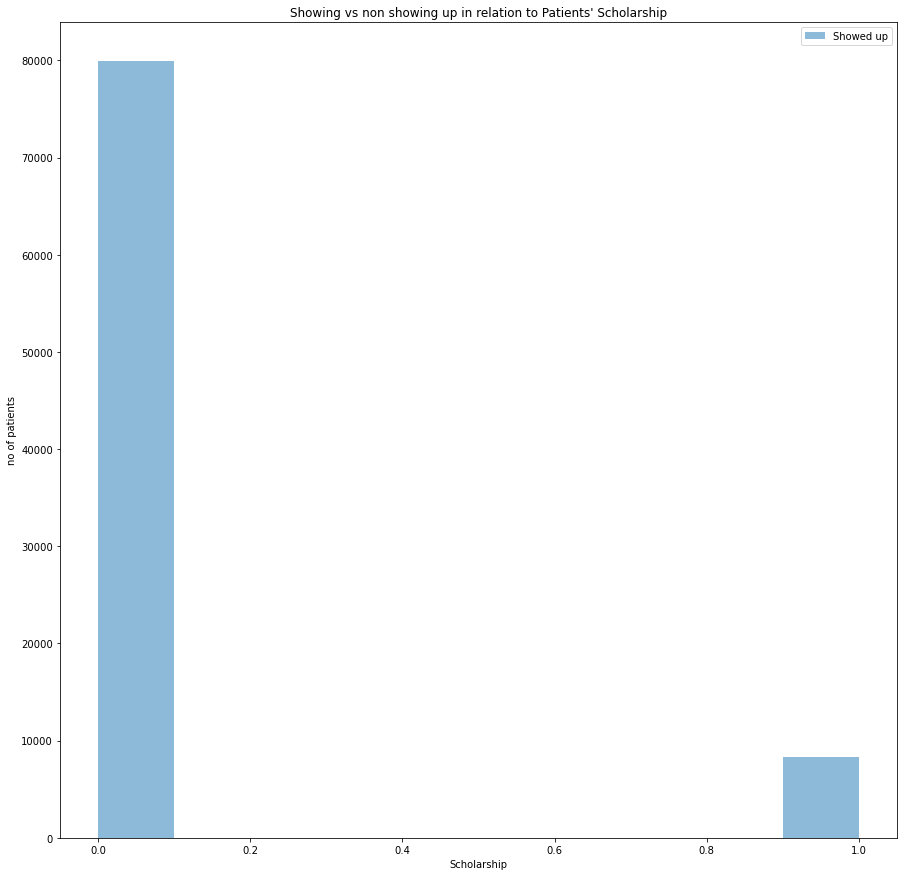

```python
#plotting scholarship data frame and its effect of not showing up
x =No_show['Scholarship']
y =show['Scholarship']

bins = 10

plt.hist(y, bins, alpha=0.5, label='Showed up')
#plt.hist(x, bins, alpha=0.8, label='Did not show up')
plt.ylabel('no of patients')
plt.xlabel('Scholarship')
plt.title("Showing vs non showing up in relation to Patients' Scholarship")
plt.legend(loc='upper right');
```

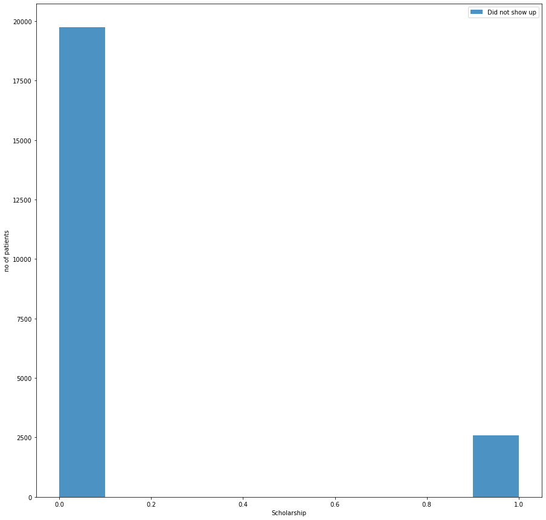

```python
#plotting scholarship data frame and its effect of not showing up
x =No_show['Scholarship']
y =show['Scholarship']

bins = 10

#plt.hist(y, bins, alpha=0.5, label='Showed up')
plt.hist(x, bins, alpha=0.8, label='Did not show up')
plt.ylabel('no of patients')
plt.xlabel('Scholarship')

plt.legend(loc='upper right');
```

Comparing the last two charts; patients who had had a scholarship didn't show-up more!

## Limitations

1 - We've removed a data entry from the original dataset. Original size 110527 and new size: 110526. And also there are 3539 data entries in which Age is defined by zero and we don't exactly know if they are not real data or they're just new-borns.  
2- Only 32% of the appointments had SMS messages received and they didn't show-up more than who didn't recevie sms. Maybe they were encouraged to enroll in SMS notifications after Non-showing up for their appointment. And patients who registered for SMS happens to have problems making appointments.

```python
#age equals zero counts
df[df.Age == 0]['Age'].value_counts()
```

```
0    3539
Name: Age, dtype: int64
```

```python
#% of patients sms received
df_sms = df['SMS_received'].value_counts()
df_all_sms= df['SMS_received'].count()
df_sms[1]/df_all_sms*100
```

```
32.10285362720084
```

## Conclusions

### Females who have medical diseases (except for ALocoholism) didn't show up more than males.

```python
from subprocess import call
call(['python', '-m', 'nbconvert', 'Investigate_a_Dataset.ipynb'])
```

```
1
```